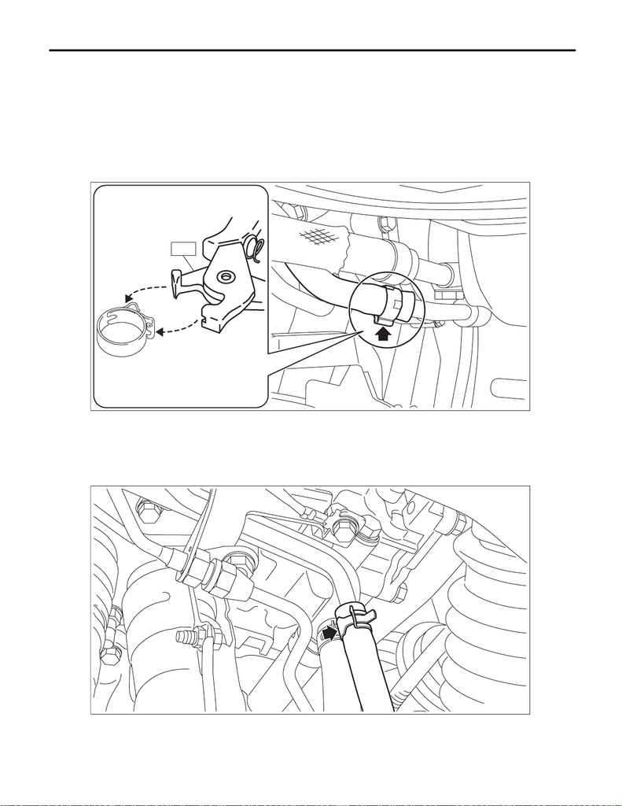

IN(w/o STI)-52

Oil Catch Tank

INTAKE (INDUCTION)

9. Oil Catch Tank

A: REMOVAL

1) Remove the air intake duct. <Ref. to IN(w/o STI)-22, REMOVAL, Air Intake Duct.>

2) Disconnect the PCV hose assembly from the oil catch tank.

NOTE:

To disconnect the PCV hose assembly, fit the cut outs of the ST with the protrusions on the clamp as shown

in the figure, squeeze the ST's handles together and unlock the clamp.

ST 18353AA000 CLAMP PLIERS

3) Lift up the vehicle.

4) Remove the under cover. <Ref. to EI-21, REMOVAL, Front Under Cover.>

5) Disconnect the turbocharger hose from the oil pipe, and drain the engine oil in the oil catch tank.

NOTE:

Prepare the container for draining of engine oil.

IN-03402

ST

IN-03338

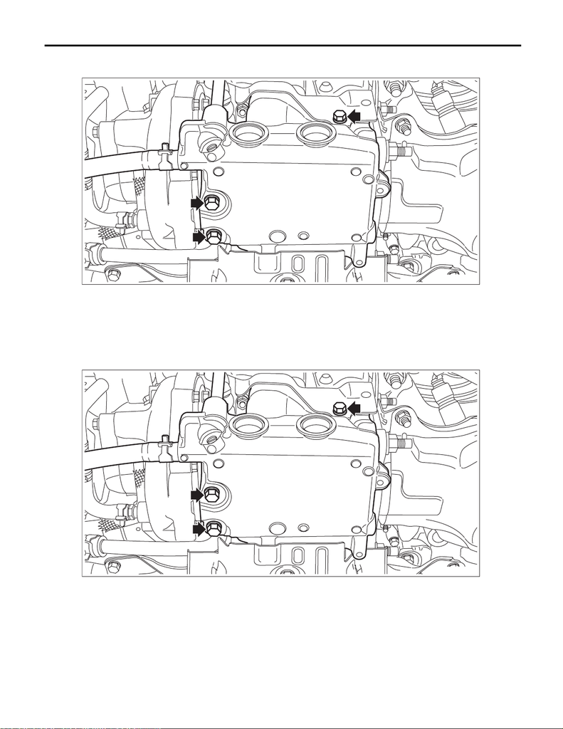

IN(w/o STI)-53

Oil Catch Tank

INTAKE (INDUCTION)

6) Remove bolts which secure the oil catch tank to the turbocharger and exhaust stay, and remove the oil

catch tank.

B: INSTALLATION

1) Install the oil catch tank to the turbocharger and exhaust stay.

(1) Set the oil catch tank to the turbocharger, and temporarily tighten the bolts which secure the oil catch

tank to the turbocharger and exhaust stay.

NOTE:

Use a new gasket.

IN-03379

IN-03379

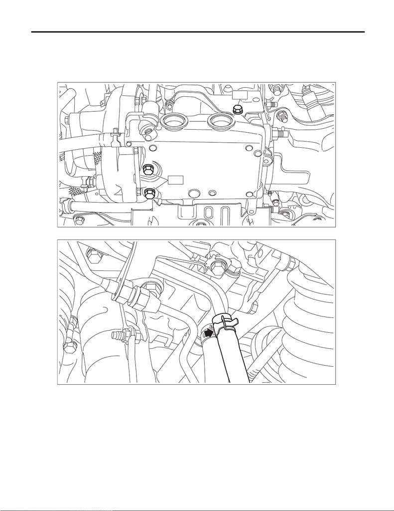

IN(w/o STI)-54

Oil Catch Tank

INTAKE (INDUCTION)

(2) Tighten the bolts which secure the oil catch tank to the turbocharger and exhaust stay in numerical or-

der as shown in the figure.

Tightening torque:

T1: 6.4 N·m (0.7 kgf-m, 4.7 ft-lb)

T2: 10.5 N·m (1.1 kgf-m, 7.7 ft-lb)

2) Connect the turbocharger hose to the oil pipe.

3) Install the under cover. <Ref. to EI-22, INSTALLATION, Front Under Cover.>

4) Lower the vehicle.

(3)

(1)

(2)

T1

T2

IN-03380

IN-03338

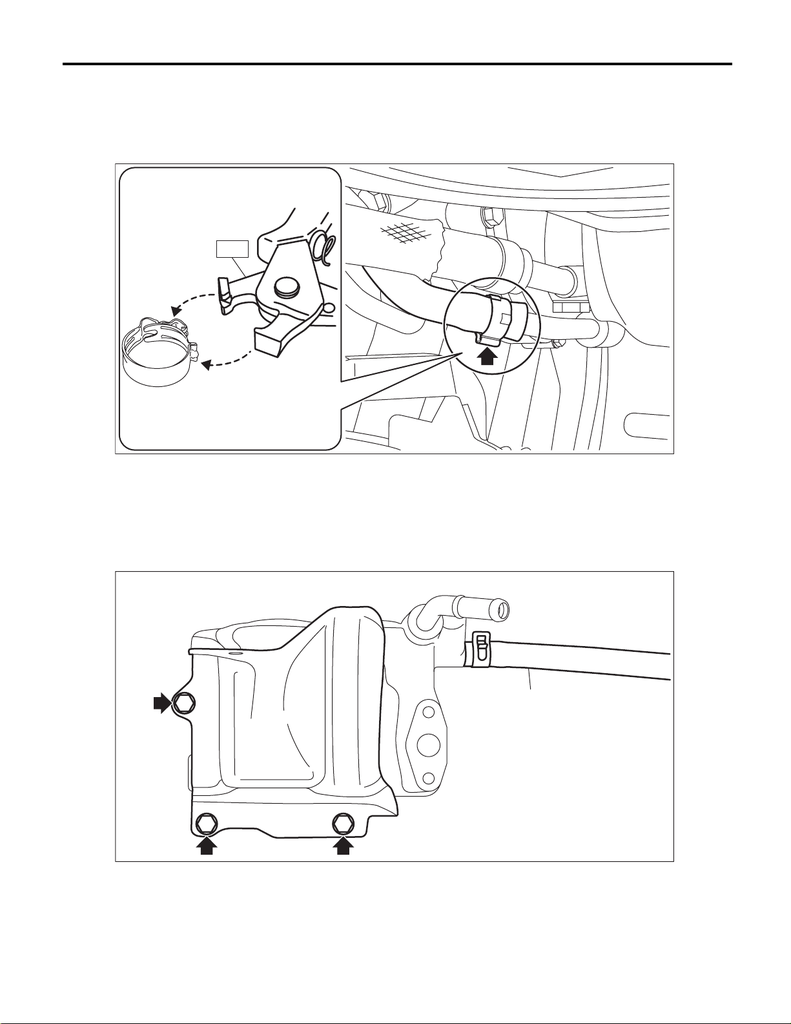

IN(w/o STI)-55

Oil Catch Tank

INTAKE (INDUCTION)

5) Connect the PCV hose assembly to the oil catch tank.

NOTE:

Use a new clamp. To connect the PCV hose assembly, fit the cut outs of the ST with the protrusions on the

clamp as shown in the figure, squeeze the ST's handles together and lock the clamp.

ST 18353AA000 CLAMP PLIERS

6) Install the air intake duct. <Ref. to IN(w/o STI)-22, INSTALLATION, Air Intake Duct.>

7) Check the engine oil level and replenish the engine oil if necessary. <Ref. to LU(w/o STI)-10, INSPEC-

TION, Engine Oil.>

C: DISASSEMBLY

Disconnect the turbo charger hose (A) from the oil catch tank, and remove the exhaust cover from the oil

catch tank.

D: ASSEMBLY

Assemble in the reverse order of disassembly.

Tightening torque:

6.4 N·m (0.7 kgf-m, 4.7 ft-lb)

IN-03644

ST

IN-03403

(A)

[figure not shown]

IN(w/o STI)-56

Oil Catch Tank

INTAKE (INDUCTION)

E: INSPECTION

1) Check that the oil catch tank does not have deformation, cracks or damage.

2) Check that the PCV hose and turbocharger hose have no cracks, damage or loose part.